title: “Single-cell RNA-seq dataset analysis - July exam” author: “Carlotta Patella” student ID number: “1085170” —

# Introduction

This analysis is based on a dataset of approximately 10,000 cells obtained with 10X Genomics 3’ technology. The goal is to analyze the cells based on gene expression, filter and annotate the data, explore structure through PCA and UMAP, identify cell clusters, assign cell types through automatic annotation, and finally infer the tissue of origin.

# Task 0 - Setup

```r
# Import libraries (the installations are managed by the Dockerfile)
library(Seurat)
library(SeuratObject)
library(ggplot2)
library(here)
library(SingleR)
library(celldex)
library(scRNAseq)
```

# Task 1 - GENE ANNOTATION

```r
# Load the GTF file
gtf <- read.table(here("Homo_sapiens.GRCh38.111.gtf"), sep = "\t", header = FALSE, comment.char = "#")
head(gtf)  # check the first lines of the file
```

```
##   V1     V2         V3     V4     V5 V6 V7 V8
## 1  1 havana       gene 182696 184174  .  +  .
## 2  1 havana transcript 182696 184174  .  +  .
## 3  1 havana       exon 182696 182746  .  +  .
## 4  1 havana       exon 183132 183216  .  +  .
## 5  1 havana       exon 183494 183571  .  +  .
## 6  1 havana       exon 183740 183901  .  +  .
##                                                                                                                                                                                                                                                                                                          …
## 1                                                                                                                                                                                                                                                                                gene_id ENSG00000279928;…
## 2                                                         gene_id ENSG00000279928; gene_version 2; transcript_id ENST00000624431; transcript_version 2; gene_name DDX11L17; gene_source havana; gene_biotype unprocessed_pseudogene; transcript_name DDX11L17-201; transcript_source havana; transcript_b…
## 3 gene_id ENSG00000279928; gene_version 2; transcript_id ENST00000624431; transcript_version 2; exon_number 1; gene_name DDX11L17; gene_source havana; gene_biotype unprocessed_pseudogene; transcript_name DDX11L17-201; transcript_source havana; transcript_biotype unprocessed_pseudogene; exon_id EN…
## 4 gene_id ENSG00000279928; gene_version 2; transcript_id ENST00000624431; transcript_version 2; exon_number 2; gene_name DDX11L17; gene_source havana; gene_biotype unprocessed_pseudogene; transcript_name DDX11L17-201; transcript_source havana; transcript_biotype unprocessed_pseudogene; exon_id EN…
## 5 gene_id ENSG00000279928; gene_version 2; transcript_id ENST00000624431; transcript_version 2; exon_number 3; gene_name DDX11L17; gene_source havana; gene_biotype unprocessed_pseudogene; transcript_name DDX11L17-201; transcript_source havana; transcript_biotype unprocessed_pseudogene; exon_id EN…
## 6 gene_id ENSG00000279928; gene_version 2; transcript_id ENST00000624431; transcript_version 2; exon_number 4; gene_name DDX11L17; gene_source havana; gene_biotype unprocessed_pseudogene; transcript_name DDX11L17-201; transcript_source havana; transcript_biotype unprocessed_pseudogene; exon_id EN…
```

```r
# Load 10X expression data from the "filtered_feature_bc_matrix" folder (contains barcodes, features, and count matrix)
data <- Read10X(data.dir = here("filtered_feature_bc_matrix"))


# Create Seurat object
seurat_obj <- CreateSeuratObject(counts = data)
seurat_obj #check the creation
```

```
## An object of class Seurat
## 36601 features across 10194 samples within 1 assay
## Active assay: RNA (36601 features, 0 variable features)
##  1 layer present: counts
```

```r
# Create a function to extract data which will be used throughout the code
extract_attribute <- function(text, key) {
  parts <- strsplit(as.character(text), ";")[[1]]
  for (part in parts) {
    part <- trimws(part)
    if (startsWith(part, key)) {
      value <- strsplit(part, " ")[[1]][2]
      value <- gsub('"', '', value)
      return(value)
    }
  }
  return(NA)
}

# From column V3 of the GTF file that contains the each gene's annotations, select only rows that are classified as "gene"
only_genes <- gtf[gtf$V3 == "gene", ]
# è un data frame

#Assess the filtration's happening by comparing initial number of data and filtered genes
nrow(gtf) #initial data
```

```
## [1] 3424897
```

```r
nrow(only_genes) #filtered genes
```

```
## [1] 63241
```

```r
head(only_genes) # preview of filtered genes
```

```
##     V1             V2   V3      V4      V5 V6 V7 V8
## 1    1         havana gene  182696  184174  .  +  .
## 8    1         havana gene 2581560 2584533  .  +  .
## 13   1 ensembl_havana gene 3069168 3438621  .  +  .
## 233  1         havana gene 5301928 5307394  .  -  .
## 239  1 ensembl_havana gene 2403964 2413797  .  -  .
## 359  1         havana gene 5492978 5494674  .  +  .
##                                                                                                                        V9
## 1   gene_id ENSG00000279928; gene_version 2; gene_name DDX11L17; gene_source havana; gene_biotype unprocessed_pseudogene;
## 8                                       gene_id ENSG00000228037; gene_version 1; gene_source havana; gene_biotype lncRNA;
## 13   gene_id ENSG00000142611; gene_version 17; gene_name PRDM16; gene_source ensembl_havana; gene_biotype protein_coding;
## 233                                     gene_id ENSG00000284616; gene_version 1; gene_source havana; gene_biotype lncRNA;
## 239   gene_id ENSG00000157911; gene_version 11; gene_name PEX10; gene_source ensembl_havana; gene_biotype protein_coding;
## 359                                     gene_id ENSG00000260972; gene_version 1; gene_source havana; gene_biotype lncRNA;
```

```r
# Extract key attributes: gene_name and gene_biotype
only_genes$gene_name <- sapply(only_genes$V9, extract_attribute, key = "gene_name")
only_genes$gene_biotype <- sapply(only_genes$V9, extract_attribute, key = "gene_biotype")

# Filter only protein-coding genes based on the gene biotype
protein_coding_genes <- only_genes[only_genes$gene_biotype == "protein_coding", ]
# Remove not-named genes to avoid mismatches that cause errors
protein_coding_names <- unique(na.omit(protein_coding_genes$gene_name))
#unique(...)Rimuove i duplicati: ogni nome di gene compare una sola volta.

# Compare initial protein coding genes' number with filtered ones
nrow(protein_coding_genes) #initial protein_coding_genes number
```

```
## [1] 20073
```

```r
length(protein_coding_names) #protein_coding_genes number after filter
```

```
## [1] 19430
```

```r
# Filter Seurat Object by using protein coding genes' gene_names
valid_names <- intersect(rownames(seurat_obj), protein_coding_names) #tiene solo i nomi che sono sia nel Seurat object sia nella lista di geni codificanti per proteine.
seurat_obj <- subset(seurat_obj, features = valid_names) #Aggiorni l’oggetto Seurat tenendo solo i geni valid_names.

# Final check of the new Object
seurat_obj
```

```
## An object of class Seurat
## 18747 features across 10194 samples within 1 assay
## Active assay: RNA (18747 features, 0 variable features)
##  1 layer present: counts
```

# Task 2 - GENE EXPRESSION SUMMARY

```r
library(ggplot2)
# Extract raw count matrix from the RNA assay of the Seurat object
counts_matrix <- GetAssayData(seurat_obj, slot = "counts") #GetAssayData() funzione di seurat che estrae dati  di uno specifico slot dell'oggetto seurat
dim(counts_matrix)
```

```
## [1] 18747 10194
```

```r
summary(counts_matrix[1:10,1:10]) #statistical summary
```

```
## 10 x 10 sparse Matrix of class "dgCMatrix", with 11 entries
##     i  j  x
## 1   6  1  1
## 2  10  1  2
## 3   5  3  1
## 4   9  3  2
## 5  10  3 11
## 6   5  6  1
## 7  10  7  1
## 8  10  8  4
## 9   9  9  1
## 10 10  9  2
## 11  5 10  1
```

```r
# Create logical matrix "genes_over_3" that defines TRUE for genes in a cell with UMI >= 3, FALSE otherwise
genes_over_3 <- counts_matrix >= 3 #Creates a logical matrix (TRUE/FALSE)

# For each column, sum TRUE values to define how many genes with UMI>=3 per cell
genes_3plus_per_cell <- colSums(genes_over_3)
summary(genes_3plus_per_cell)  #summary stats
```

```
##    Min. 1st Qu.  Median    Mean 3rd Qu.    Max.
##    10.0   271.0   359.0   491.9   639.0  3575.0
```

```r
# Add a new column to Seurat object metadata called "Gene3plus" for each cell
seurat_obj$Genes3plus <- genes_3plus_per_cell
head(seurat_obj@meta.data$Genes3plus)
```

```
## [1] 1330  373 1254   12 1017  413
```

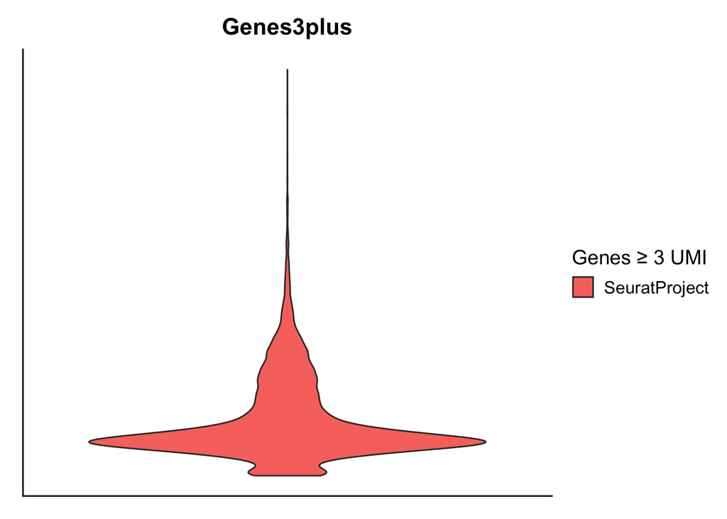

```r
# Violin plot showing distribution of number of genes with ≥3 UMI per cell
VlnPlot(seurat_obj, features = "Genes3plus", pt.size = 0) +
  theme(axis.title = element_blank(), axis.text = element_blank(), axis.ticks = element_blank(),axis.text.x = element_blank()) + labs(fill = "Genes ≥ 3 UMI")
```

# Task 3 - GENE FILTERING

```r
# Find mitochondrial genes in Seurat Object (start with MT-)
mt_genes <- grep("^MT-", rownames(seurat_obj), value = TRUE)
# Find ribosomal proteins in Seurat Object (start with RPL or RPS)
ribo_proteins <- grep("^(RPL|RPS)", rownames(seurat_obj), value = TRUE)

# Mitochondrial pseudogenes should have already been filtered at task 1, when filtering for "genes", that automatically excludes pseudogenes


# Unite the filtered ribosomal proteins and mitochondrial genes into th genes_to_remove list
genes_to_remove <- union(mt_genes, ribo_proteins)

# Create a summary table of filtered genes by category
data.frame(
  Category = c("Mitochondrial_genes", "Ribosomal_proteins"),
  Genes_removed = c(length(mt_genes), length(ribo_proteins))
)
```

```
##              Category Genes_removed
## 1 Mitochondrial_genes            13
## 2  Ribosomal_proteins            99
```

```r
# Create a list "genes_to_keep" that contains genes from the SeuratObject except the ones to remove
genes_to_keep <- setdiff(rownames(seurat_obj), genes_to_remove)
# Mantain in SeuratObject only the previously filtered list
seurat_obj <- subset(seurat_obj, features = genes_to_keep)
```

# Task 4 - Principal Component Analysis (PCA)

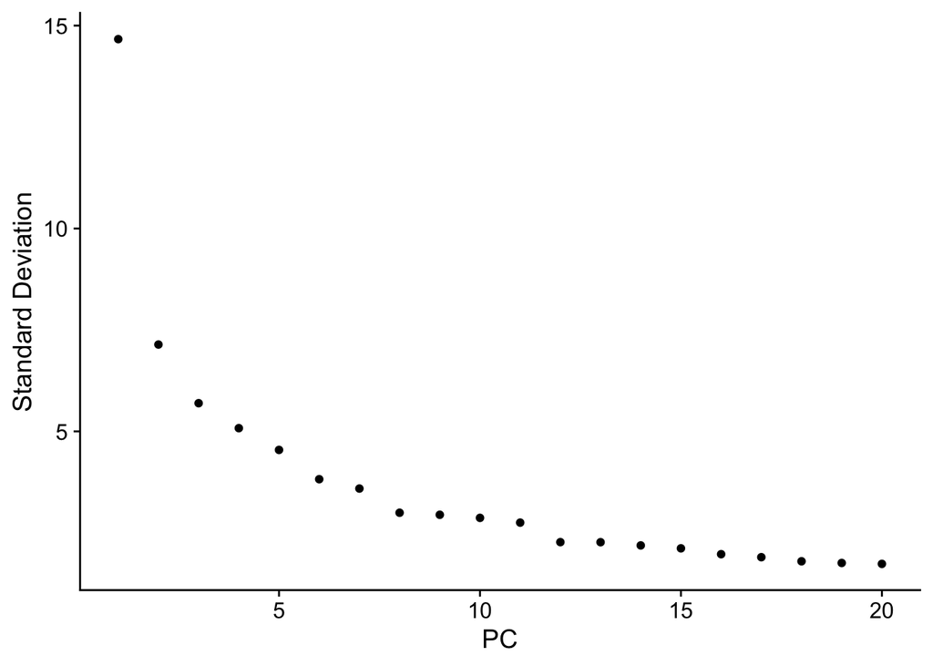

```r
# Normalize data
seurat_obj <- NormalizeData(seurat_obj)
# Identify highly variable genes
seurat_obj <- FindVariableFeatures(seurat_obj)
# Scale data
seurat_obj <- ScaleData(seurat_obj)
# Perform PCA
seurat_obj <- RunPCA(seurat_obj)
# Elbow plot to visualize variance explained by the first 20 principal components
ElbowPlot(seurat_obj, ndims = 20)
```